# hw5

```python
import numpy as np
import matplotlib
import matplotlib.pyplot as plt
import scipy
import random
import statistics
from scipy import stats
```

**Problem 1**

First start by throwing a signal-free background. For Problem 1 choose a Normal distribution with some modest σ , say in the range 2-5. Create a million background events.

Now we need to make some signal. Let us choose to make signals of random strength on the interval of 0-20. Now it is critically important that you throw these using a uniform distribution. A uniform distribution means that the signal is equally likely to be small/faint (near zero) as large/bright (near 20). Mathematically this is the P(signal) in the equation. If you use another way of simulating signals that does not have a uniform distribution, you are injecting an implicit prior (very, very bad).

Now add your signal to your background to create fake data readings. Since you know what the true signal was for each data reading, and you used a flat prior, you now have P(data|signal)P(signal) .

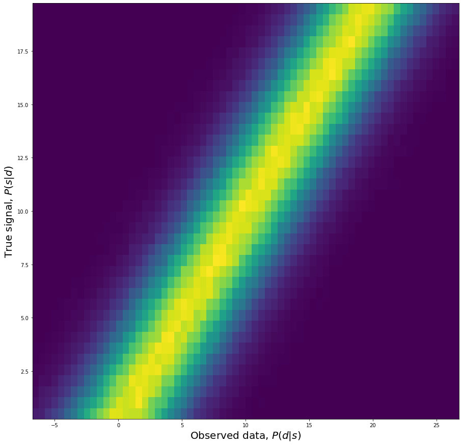

```python
bkgd = stats.norm.rvs(loc = 0, size = 1000000, scale = 3)
signal = stats.uniform.rvs(loc = 0, scale = 20, size = 1000000)
data = bkgd + signal

plt.subplots(figsize=(15,15))
signaledges = np.linspace(0,20,40)
dataedges = np.linspace(-7,27,68)

Psd, temp, temp2= np.histogram2d(data,signal, bins=[dataedges,signaledges], density=True)

datacenters = (dataedges[:-1] + dataedges[1:]) / 2
signalcenters = (signaledges[:-1] + signaledges[1:]) / 2
plt.pcolormesh(datacenters,signalcenters,Psd.T)
plt.ylabel('True signal, $P(s|d)$', fontsize = 20)
plt.xlabel('Observed data, $P(d|s)$', fontsize = 20)
```

Now to explore this we can take slices of the above. We can look at our array edges and pick a vertical or horizontal stripe.

Problem 1b

Select a true injected signal and plot P(d|s) . (Use a stair style plot). Label your plot and clearly explain what you are plotting and how to interpret it.

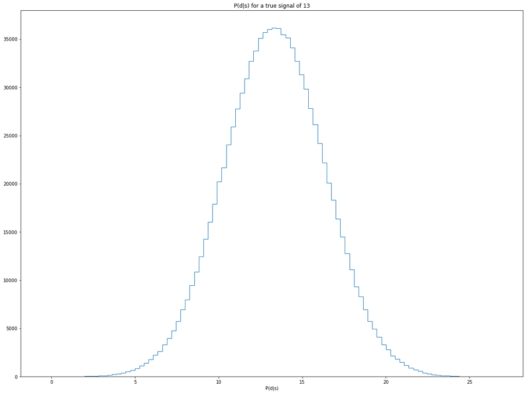

```python
signal = bkgd + signaledges[26]
plt.subplots(1, 1)
plt.hist(signal, 100,histtype = 'step')
plt.title('P(d|s) for a true signal of 13')
plt.xlabel('P(d|s)')
plt.show()
```

From the graph above, it shows that given a true signal which is 13, the probability of getting the particular data values.

Problem 1c

Select an observed data value and plot P(s|d) . (Use a stair style plot). Label your plot and clearly explain what you are plotting and how to interpret it.

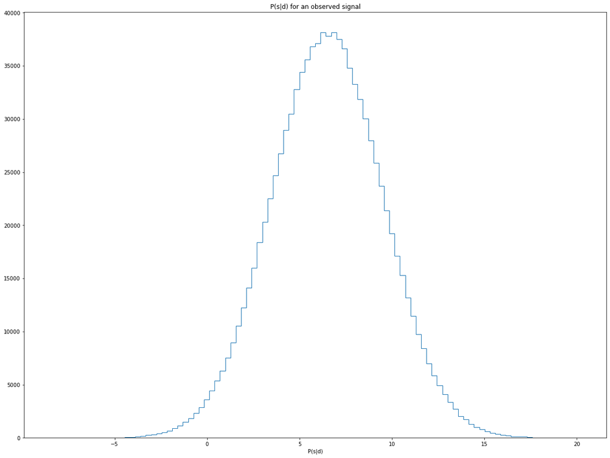

```python
observedsignal = 6.5
injectedsignal = observedsignal - bkgd
plt.subplots(1, 1)
plt.hist(injectedsignal, 100, histtype = 'step')
plt.title('P(s|d) for an observed signal')
plt.xlabel('P(s|d)')
plt.show()
```

From the graph above, it shows the distribution of if i measure the observed data which is 6.5, what is the probability of the true signal strength.

**Problem 2**

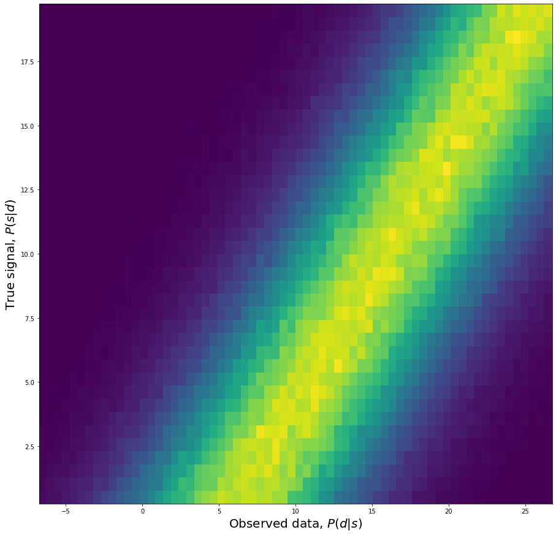

```python
plt.subplots(figsize=(15,15))
bkgd2 =  stats.norm.rvs(loc=6,scale=5,size=1000000)
signal2 = stats.uniform.rvs(loc=0, scale=20, size=1000000)
data2 = bkgd2 + signal2

signaledges2 = np.linspace(0,20,40)
dataedges2 = np.linspace(-7,27,68)

Psd2, temp2, temp22= np.histogram2d(data2,signal2, bins=[dataedges2,signaledges2], density=True)

datacenters2 = (dataedges2[:-1] + dataedges2[1:]) / 2
signalcenters2 = (signaledges2[:-1] + signaledges2[1:]) / 2
plt.pcolormesh(datacenters2,signalcenters2,Psd2.T)
plt.ylabel('True signal, $P(s|d)$', fontsize = 20)
plt.xlabel('Observed data, $P(d|s)$', fontsize = 20);
```

Problem 2b

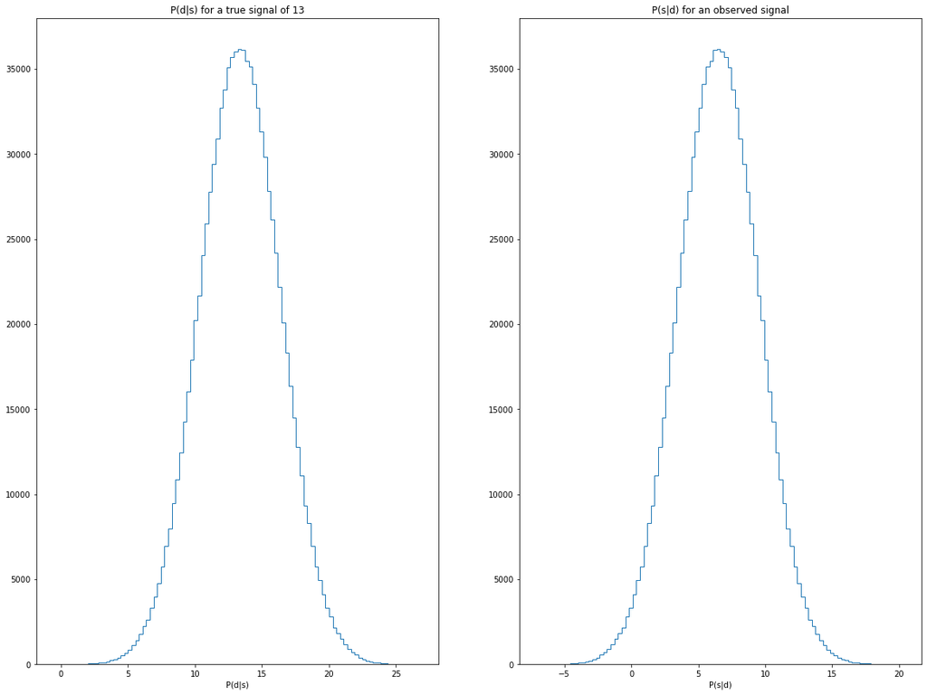

```python
plt.rcParams["figure.figsize"] = (20,15)
plt.subplot(1,2,1)
signal = bkgd + signaledges[26]
plt.hist(signal, 100,histtype = 'step')
plt.title('P(d|s) for a true signal of 13')
plt.xlabel('P(d|s)')
plt.subplot(1,2,2)
observedsignal = 6.5
injectedsignal = observedsignal - bkgd
plt.hist(injectedsignal, 100, histtype = 'step')
plt.title('P(s|d) for an observed signal')
plt.xlabel('P(s|d)')
plt.show()
```

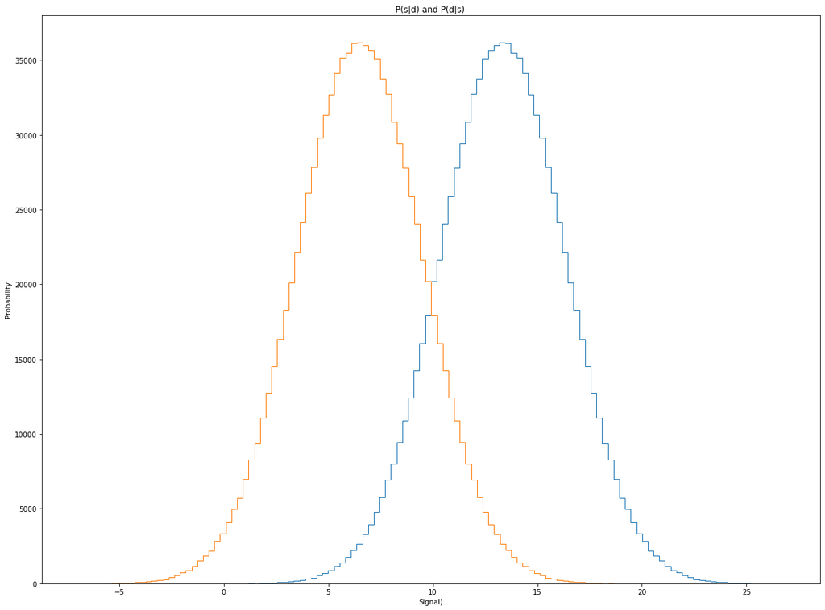

```python
plt.subplots(1, 1)
plt.hist(signal, 100,histtype = 'step',label = "P(d|s)" )
plt.hist(injectedsignal, 100, histtype = 'step',label = "P(s|d)")
plt.title('P(s|d) and P(d|s) ')
plt.xlabel('Signal)')
plt.ylabel('Probability')
```

```python
meansignal =np.mean(signal)
meaninjectedsignal = np.mean(injectedsignal)
print(meansignal)
print(meaninjectedsignal)
```

```
13.335951727028263
6.497381606305066
```